# Predicting US Salaries - Ryan Bradley

First, the necessary packages/libraries and data need to be loaded to perform the analyses. The data for this analysis has been obtained from the [UCI Machine Learning Repositoriy](https://archive.ics.uci.edu/ml/datasets/Adult).

```r
library(tidyverse)
library(modelr)
data  <- read_csv("https://archive.ics.uci.edu/ml/machine-learning-databases/adult/adult.data",
                  col_types = cols(), col_names = FALSE)
names <- c("Age", "Work_Class", "fnlwgt", "Education", "Education_Years", "Marial Status", "Occupation", "Relationship", "Race", "Sex", "Capital Gain", "Capital Loss", "Hours_Per_Week", "Native Country", "Salary")
colnames(data) <- names
data <- data %>%
  mutate(Salary = ifelse(Salary == "<=50K", 0, 1),
         Fulltime = ifelse(Hours_Per_Week >= 40, "Yes", "No"),
         Age_Bin = ifelse(Age < 25, "18 – 24",
                          ifelse(Age < 35, "25 – 34",
                                 ifelse(Age < 45, "35 – 44",
                                        ifelse(Age < 55, "45 – 54",
                                               ifelse(Age < 65, "55 – 64", "65+")))))
         )
average_age <- mean(data$Age)
average_education_years <- mean(data$Education_Years)
# Function to convert the coefficient estimates into odds and probabilities for
# the coefficient indices provided in the odds and probs parameters
odds_and_probs <- function(logistic_model, odds = c(1), probs=c(1)) {
  data <- summary(logistic_model, digits = 3)$coefficients %>%
    as.data.frame() %>%
    rename(`p-value` = `Pr(>|z|)`) %>%
    mutate(`Odds(ratio)` = exp(coefficients(logistic_model)),
           Probability = plogis(coefficients(logistic_model)),
           Significance = as.factor(symnum(`p-value`, na = FALSE,
                     cutpoints = c(0, 0.001, 0.01, 0.05, 0.1, 1),
                     symbols = c("***", "**", "*", ".", " "))),
           Probability = ifelse(row_number() %in% probs, Probability, NA),
           `Odds(ratio)` = ifelse(row_number() %in% odds, `Odds(ratio)`, NA)
    ) %>%
    select(1, 5, 6, 2, 4, 7, 3)



  row.names(data) <- row.names(summary(logistic_model)$coefficients)

  data
}
# Calculates the predicted value for each of the grade levels for a given model
# Converts these predicted values to their corresponding Odds and Probability values
predicted_probabilities <- function(logistic_model, data, variable_value = 0, variable_name = "Age", pivot_variable = "Sex") {
  if (pivot_variable == "Sex") {
    temp <-data_grid(data, Sex) %>%
      mutate(Variable = variable_value)
  } else if (pivot_variable == "Work_Class") {
    temp <-data_grid(data, Work_Class) %>%
      mutate(Variable = variable_value)
  } else if (pivot_variable == "Fulltime") {
    temp <-data_grid(data, Fulltime) %>%
      mutate(Variable = variable_value)
  } else if (pivot_variable == "Age_Bin") {
    temp <-data_grid(data, Age_Bin) %>%
      mutate(Variable = variable_value)
  }

  variable_index <- length(colnames(temp))
  colnames(temp) <- c(colnames(temp)[1:variable_index-1], variable_name)

  temp <- temp %>%
    add_predictions(logistic_model) %>%
    mutate(Odds = exp(pred),
           Probability = plogis(pred)) %>%
    rename(`Predicted Value` = pred)

  temp %>% select(-variable_index)
}
# Caclulates the pseudo R2 values for the given logistic regression model
pseudo_r2 <- function(logistic_model) {

  mcfadden <- function(m) { m.null <- update(m, . ~ 1); LLf <- logLik(m); LL0 <- logLik(m.null); as.vector(1-(LLf/LL0))}
  coxsnell <- function(m) { m.null <- update(m, . ~ 1); LLf <- logLik(m); LL0 <- logLik(m.null); N <- length(resid(m)); as.vector(1 - exp((2/N) * (LL0 - LLf)))}
  nagelkerke <- function(m) { m.null <- update(m, . ~ 1); LLf <- logLik(m); LL0 <- logLik(m.null); N <- length(resid(m)); as.vector((1 - exp((2/N) * (LL0 - LLf))) / (1 - exp(LL0)^(2/N)))}

  list(McFadden=mcfadden(logistic_model), CoxSnell=coxsnell(logistic_model), Nagelkerke=nagelkerke(logistic_model))
}
predicted_data <- function(logistic_model, data) {
  data %>%
    add_predictions(logistic_model) %>%
    mutate(prob=plogis(pred),
           Guess = ifelse(prob >= 0.50, 1, 0))
}
predictive_percentage <- function(predicted_data) {
  if (exists("baseline_accuracy")) {
    predicted_data %>%
      summarize(Accuracy = mean(Guess == Salary, na.rm=T)*100) %>%
      mutate(Baseline.Difference = Accuracy - baseline_accuracy)
  } else {
    predicted_data %>%
      summarize(Accuracy = mean(Guess == Salary, na.rm=T)*100) %>%
      mutate(Baseline.Difference = NA)
  }
}
confusion_matrix <- function(predicted_data) {
  with(predicted_data, table(Salary, Guess))
}
```

The overall research question that we are trying to answer here is “What factors lead to higher paying salaries?”

To study this question, we will carefully examine a number of different predictors and examine their influence on our dependent variable `*Salary*`.

Lets look at some simple descriptive statistics for our data

```r
descriptives <- data %>% select(Age, Education_Years, Hours_Per_Week) %>% summarise_all(funs(min, median, mean, max, sd))
descriptives[, as.character((data.frame(names = names(descriptives)) %>% arrange(names))$names)]
```

| Age_max | Age_mean | Age_median | Age_min | Age_sd | Education_Years_max | Education_Years_mean | Education_Years_median | Education_Years_min | Education_Years_sd | Hours_Per_Week_max | Hours_Per_Week_mean | Hours_Per_Week_median | Hours_Per_Week_min | Hours_Per_Week_sd |
| --- | --- | --- | --- | --- | --- | --- | --- | --- | --- | --- | --- | --- | --- | --- |
| 90 | 38.58165 | 37 | 17 | 13.64043 | 16 | 10.08068 | 10 | 1 | 2.57272 | 99 | 40.43746 | 40 | 1 | 12.34743 |

```r
data %>%
  select(Sex, Fulltime) %>%
  mutate(Sex = ifelse(Sex == "Female", 1, 0),
         Fulltime = ifelse(Fulltime == "Yes", 1, 0)) %>%
  summarise(Sex = mean(Sex), Fulltime = mean(Fulltime, na.rm = T))
```

| Sex | Fulltime |
| --- | --- |
| 0.3307945 | 0.7615859 |

```r
data %>%
  group_by(Sex) %>%
  summarise(count = n()) %>%
  mutate(Percentage = count / nrow(data) * 100,
         Variable = "Sex") %>%
  rename(Value = Sex) %>%
  bind_rows(
    data %>%
      group_by(Fulltime) %>%
      summarise(count = n()) %>%
      mutate(Percentage = count / nrow(data) * 100,
             Variable = "Full-time") %>%
      rename(Value = Fulltime)
  ) %>%
  bind_rows(
    data %>%
      select(Age_Bin) %>%
      group_by(Age_Bin) %>%
      summarise(count = n()) %>%
      mutate(Percentage = count / nrow(data) * 100,
             Variable = "Age Range") %>%
      rename(Value = Age_Bin)
  ) %>%
  bind_rows(
    data %>%
      group_by(Salary) %>%
      summarise(count = n()) %>%
      mutate(Percentage = count / nrow(data) * 100,
             Variable = "Salary",
             Salary = as.character(Salary)) %>%
      rename(Value = Salary)
  ) %>%
  select(Variable, Value, count, Percentage)
```

| Variable | Value | count | Percentage |
| --- | --- | --- | --- |
| Sex | Female | 10771 | 33.079451 |
| Sex | Male | 21790 | 66.920549 |
| Full-time | No | 7763 | 23.841405 |
| Full-time | Yes | 24798 | 76.158595 |
| Age Range | 18 – 24 | 5570 | 17.106354 |
| Age Range | 25 – 34 | 8479 | 26.040355 |
| Age Range | 35 – 44 | 8151 | 25.033015 |
| Age Range | 45 – 54 | 5853 | 17.975492 |
| Age Range | 55 – 64 | 3172 | 9.741716 |
| Age Range | 65+ | 1336 | 4.103068 |

[output cut: 2 more lines]

An initial baseline model has been generated for pseudo R<sup>2</sup> comparisons. If we simply guess that every individual will have a salary below $50,000, then our baseline accuracy is 75.92%.

```r
temp_data <- data %>% mutate(Guess = 0)
(baseline_accuracy <- predictive_percentage(temp_data))
```

| Accuracy | Baseline.Difference |
| --- | --- |
| 75.91904 | NA |

```r
baseline_accuracy <- baseline_accuracy$Accuracy
```

```r
confusion_matrix(temp_data)
```

```
      Guess
Salary     0
     0 24720
     1  7841
```

##### 1. Does an individuals age lead to a higher salary?

```r
age_model <- glm(Salary ~ Age, data=data, family=binomial(logit))
odds_and_probs(age_model, odds = c(1, 2))
```

|  | Estimate | Odds(ratio) | Probability | Std. Error | p-value | Significance | z value |
| --- | --- | --- | --- | --- | --- | --- | --- |
| (Intercept) | -2.74404178 | 0.06430989 | 0.06042403 | 0.0427350718 | 0 | *** | -64.21053 |
| Age | 0.03953173 | 1.04032351 | NA | 0.0009674367 | 0 | *** | 40.86234 |

```r
pseudo_r2(age_model)
```

```
$McFadden
[1] 0.0485855

$CoxSnell
[1] 0.05222627

$Nagelkerke
[1] 0.05222627
```

```r
temp_data <- predicted_data(age_model, data)
predictive_percentage(temp_data)
```

| Accuracy | Baseline.Difference |
| --- | --- |
| 74.68137 | -1.237677 |

```r
confusion_matrix(temp_data)
```

```
      Guess
Salary     0     1
     0 24204   516
     1  7728   113
```

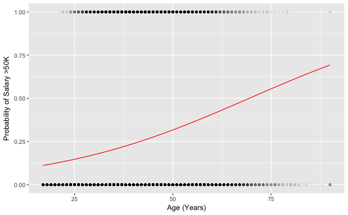

```r
fake_data <- data_grid(data, Age=seq_range(Age, 25)) %>% add_predictions(age_model) %>% mutate(prob = plogis(pred))
ggplot(data) + geom_point(aes(Age, Salary), alpha = 0.012) + geom_line(aes(Age, prob), data=fake_data, color="red") + labs(x="Age (Years)", y="Probability of Salary >50K")
```

##### 1.5. Does an individuals age lead to a higher salary?

```r
age_bin_model <- glm(Salary ~ Age_Bin * Age, data=data, family=binomial(logit))
odds_and_probs(age_bin_model, odds = c(1, 7:12))
```

|  | Estimate | Odds(ratio) | Probability | Std. Error | p-value | Significance | z value |
| --- | --- | --- | --- | --- | --- | --- | --- |
| (Intercept) | -19.8170488 | 2.474942e-09 | 2.474942e-09 | 2.3832930 | 9.176272e-17 | *** | -8.314986 |
| Age_Bin25 – 34 | 13.1169254 | NA | NA | 2.4059453 | 4.984007e-08 | *** | 5.451880 |
| Age_Bin35 – 44 | 17.2233960 | NA | NA | 2.4054580 | 8.059966e-13 | *** | 7.160132 |
| Age_Bin45 – 54 | 18.9785815 | NA | NA | 2.4278084 | 5.402582e-15 | *** | 7.817166 |
| Age_Bin55 – 64 | 21.9479826 | NA | NA | 2.5177994 | 2.853446e-18 | *** | 8.717129 |
| Age_Bin65+ | 20.5246743 | NA | NA | 2.5426937 | 6.914461e-16 | *** | 8.072020 |
| Age | 0.6906031 | 1.994918e+00 | NA | 0.1032440 | 2.246444e-11 | *** | 6.689037 |
| Age_Bin25 – 34:Age | -0.5206536 | 5.941321e-01 | NA | 0.1038041 | 5.283141e-07 | *** | -5.015734 |
| Age_Bin35 – 44:Age | -0.6425615 | 5.259435e-01 | NA | 0.1035718 | 5.503955e-10 | *** | -6.204018 |
| Age_Bin45 – 54:Age | -0.6816705 | 5.057714e-01 | NA | 0.1036733 | 4.859458e-11 | *** | -6.575179 |

[output cut: 2 more lines]

```r
pseudo_r2(age_bin_model)
```

```
$McFadden
[1] 0.1220823

$CoxSnell
[1] 0.1260933

$Nagelkerke
[1] 0.1260933
```

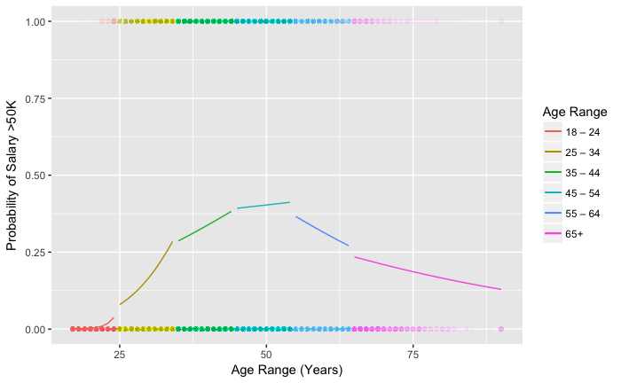

```r
fake_data_24 <- data_grid(data, Age_Bin = "18 – 24", Age=seq(min(data$Age), 24)) %>% add_predictions(age_bin_model) %>% mutate(prob = plogis(pred))
fake_data_34 <- data_grid(data, Age_Bin = "25 – 34", Age=seq(25, 34)) %>% add_predictions(age_bin_model) %>% mutate(prob = plogis(pred))
fake_data_44 <- data_grid(data, Age_Bin = "35 – 44", Age=seq(35, 44)) %>% add_predictions(age_bin_model) %>% mutate(prob = plogis(pred))
fake_data_54 <- data_grid(data, Age_Bin = "45 – 54", Age=seq(45, 54)) %>% add_predictions(age_bin_model) %>% mutate(prob = plogis(pred))
fake_data_64 <- data_grid(data, Age_Bin = "55 – 64", Age=seq(55, 64)) %>% add_predictions(age_bin_model) %>% mutate(prob = plogis(pred))
fake_data_plus <- data_grid(data, Age_Bin = "65+", Age=seq(65, max(data$Age))) %>% add_predictions(age_bin_model) %>% mutate(prob = plogis(pred))
ggplot(data) + geom_point(aes(Age, Salary, color=Age_Bin), alpha = 0.012, show.legend = F) + geom_line(aes(Age, prob, color=Age_Bin), data=fake_data_24) + geom_line(aes(Age, prob, color=Age_Bin), data=fake_data_34) + geom_line(aes(Age, prob, color=Age_Bin), data=fake_data_44) + geom_line(aes(Age, prob, color=Age_Bin), data=fake_data_54) + geom_line(aes(Age, prob, color=Age_Bin), data=fake_data_64) + geom_line(aes(Age, prob, color=Age_Bin), data=fake_data_plus) + labs(x="Age Range (Years)", y="Probability of Salary >50K", colour="Age Range")
```

##### 2. Does an individuals Gender affect their salary?

```r
gender_model <- glm(Salary ~ Sex, data=data, family=binomial(logit))
odds_and_probs(gender_model)
```

|  | Estimate | Odds(ratio) | Probability | Std. Error | p-value | Significance | z value |
| --- | --- | --- | --- | --- | --- | --- | --- |
| (Intercept) | -2.096263 | 0.1229149 | 0.1094606 | 0.03086056 | 0.00000e+00 | *** | -67.92692 |
| SexMale | 1.276135 | NA | NA | 0.03418452 | 5.19814e-305 | *** | 37.33079 |

```r
predicted_probabilities(gender_model, data)
```

| Sex | Predicted Value | Odds | Probability |
| --- | --- | --- | --- |
| Female | -2.0962628 | 0.1229149 | 0.1094606 |
| Male | -0.8201276 | 0.4403755 | 0.3057366 |

```r
pseudo_r2(gender_model)
```

```
$McFadden
[1] 0.04667521

$CoxSnell
[1] 0.0502253

$Nagelkerke
[1] 0.0502253
```

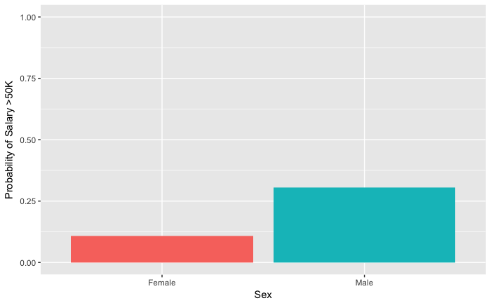

```r
fake_data <- data_grid(data, Sex) %>% add_predictions(gender_model) %>% mutate(prob = plogis(pred))
ggplot(fake_data) + geom_bar(aes(Sex, prob, fill=Sex), stat="identity", show.legend=FALSE) + ylim(0,1) + labs(x="Sex", y="Probability of Salary >50K")
```

##### 3. Controling for an individuals Gender, does an individuals age still influence their salary?

```r
both_model <- glm(Salary ~ Sex + Age_Bin, data=data, family=binomial(logit))
odds_and_probs(both_model)
```

|  | Estimate | Odds(ratio) | Probability | Std. Error | p-value | Significance | z value |
| --- | --- | --- | --- | --- | --- | --- | --- |
| (Intercept) | -5.327274 | 0.004857293 | 0.004833814 | 0.13199865 | 0.000000e+00 | *** | -40.35855 |
| SexMale | 1.205844 | NA | NA | 0.03542019 | 4.981975e-254 | *** | 34.04399 |
| Age_Bin25 – 34 | 2.820994 | NA | NA | 0.13225718 | 6.031124e-101 | *** | 21.32961 |
| Age_Bin35 – 44 | 3.719074 | NA | NA | 0.13116905 | 7.624698e-177 | *** | 28.35329 |
| Age_Bin45 – 54 | 4.031134 | NA | NA | 0.13182581 | 2.310985e-205 | *** | 30.57924 |
| Age_Bin55 – 64 | 3.671523 | NA | NA | 0.13467421 | 1.189450e-163 | *** | 27.26225 |
| Age_Bin65+ | 3.081730 | NA | NA | 0.14616433 | 1.115282e-98 | *** | 21.08401 |

```r
data_grid(data, Sex, Age_Bin) %>%
    add_predictions(both_model) %>%
    mutate(Odds = exp(pred),
           Probability = plogis(pred)) %>%
    rename(`Predicted Value` = pred)
```

| Sex | Age_Bin | Predicted Value | Odds | Probability |
| --- | --- | --- | --- | --- |
| Female | 18 – 24 | -5.32727399 | 0.004857293 | 0.004833814 |
| Female | 25 – 34 | -2.50628021 | 0.081571103 | 0.075419085 |
| Female | 35 – 44 | -1.60820041 | 0.200247653 | 0.166838613 |
| Female | 45 – 54 | -1.29614020 | 0.273585744 | 0.214815332 |
| Female | 55 – 64 | -1.65575145 | 0.190948514 | 0.160333139 |
| Female | 65+ | -2.24554416 | 0.105869915 | 0.095734510 |
| Male | 18 – 24 | -4.12142968 | 0.016221307 | 0.015962376 |
| Male | 25 – 34 | -1.30043590 | 0.272413021 | 0.214091664 |
| Male | 35 – 44 | -0.40235611 | 0.668742560 | 0.400746392 |
| Male | 45 – 54 | -0.09029589 | 0.913660800 | 0.477441352 |

[output cut: 2 more lines]

```r
pseudo_r2(both_model)
```

```
$McFadden
[1] 0.1486707

$CoxSnell
[1] 0.1513733

$Nagelkerke
[1] 0.1513733
```

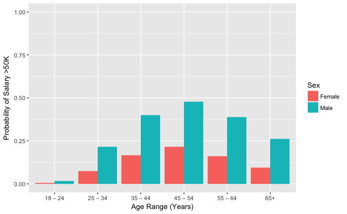

```r
fake_data <- data_grid(data, Sex, Age_Bin) %>% add_predictions(both_model) %>% mutate(prob=plogis(pred))
ggplot(fake_data, aes(Age_Bin, prob)) + geom_bar(aes(fill = Sex), stat="identity", position = "dodge") + ylim(0,1) + labs(x="Age Range (Years)", y="Probability of Salary >50K")
```

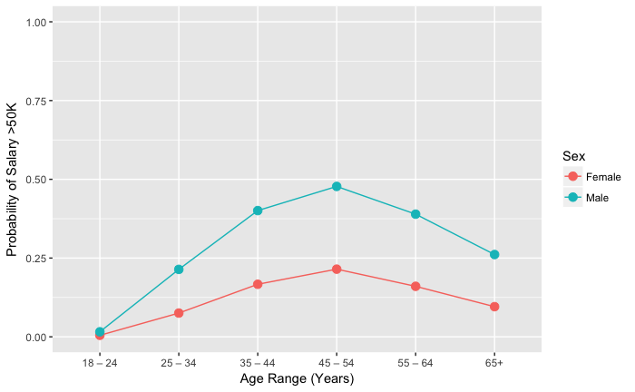

```r
ggplot(fake_data, aes(x=Age_Bin, y=prob, group=Sex, colour=Sex)) + geom_line() + geom_point(size=3) + ylim(0,1) + labs(y="Probability of Salary >50K", x="Age Range (Years)")
```

##### 4. Does an individuals level of Education affect their salary?

```r
education_model <- glm(Salary ~ Education_Years, data=data, family=binomial(logit))
odds_and_probs(education_model, odds = c(1, 2))
```

|  | Estimate | Odds(ratio) | Probability | Std. Error | p-value | Significance | z value |
| --- | --- | --- | --- | --- | --- | --- | --- |
| (Intercept) | -5.0197309 | 0.006606304 | 0.006562947 | 0.070761690 | 0 | *** | -70.93854 |
| Education_Years | 0.3642949 | 1.439498664 | NA | 0.006277275 | 0 | *** | 58.03392 |

```r
pseudo_r2(education_model)
```

```
$McFadden
[1] 0.112571

$CoxSnell
[1] 0.1168683

$Nagelkerke
[1] 0.1168683
```

```r
temp_data <- predicted_data(education_model, data)
predictive_percentage(temp_data)
```

| Accuracy | Baseline.Difference |
| --- | --- |
| 77.95829 | 2.039249 |

```r
confusion_matrix(temp_data)
```

```
      Guess
Salary     0     1
     0 23696  1024
     1  6153  1688
```

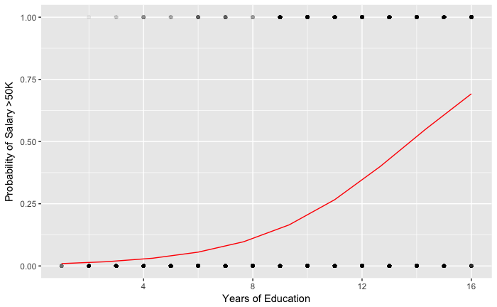

```r
fake_data <- data_grid(data, Education_Years=seq_range(Education_Years, 10)) %>% add_predictions(education_model) %>% mutate(prob = plogis(pred))
ggplot(data) + geom_point(aes(Education_Years, Salary), alpha = 0.012) + geom_line(aes(Education_Years, prob), data=fake_data, color="red") + labs(x="Years of Education", y="Probability of Salary >50K")
```

##### 5. Controling for an individuals Gender, does an individuals Education level still influence their salary?

```r
education_gender_model <- glm(Salary ~ Sex + Education_Years, data=data, family=binomial(logit))
odds_and_probs(education_gender_model, odds = c(1, 3))
```

|  | Estimate | Odds(ratio) | Probability | Std. Error | p-value | Significance | z value |
| --- | --- | --- | --- | --- | --- | --- | --- |
| (Intercept) | -6.1107816 | 0.002218816 | 0.002213904 | 0.080480467 | 0 | *** | -75.92875 |
| SexMale | 1.3616674 | NA | NA | 0.035967016 | 0 | *** | 37.85878 |
| Education_Years | 0.3724347 | 1.451263707 | NA | 0.006462165 | 0 | *** | 57.63312 |

```r
predicted_probabilities(education_gender_model, data, variable_name = "Education_Years", variable_value = average_education_years)
```

| Sex | Predicted Value | Odds | Probability |
| --- | --- | --- | --- |
| Female | -2.3563868 | 0.0947620 | 0.08655945 |
| Male | -0.9947194 | 0.3698272 | 0.26998092 |

```r
pseudo_r2(education_gender_model)
```

```
$McFadden
[1] 0.1599551

$CoxSnell
[1] 0.16188

$Nagelkerke
[1] 0.16188
```

```r
temp_data <- predicted_data(education_gender_model, data)
predictive_percentage(temp_data)
```

| Accuracy | Baseline.Difference |
| --- | --- |
| 78.57253 | 2.653481 |

```r
confusion_matrix(temp_data)
```

```
      Guess
Salary     0     1
     0 22285  2435
     1  4542  3299
```

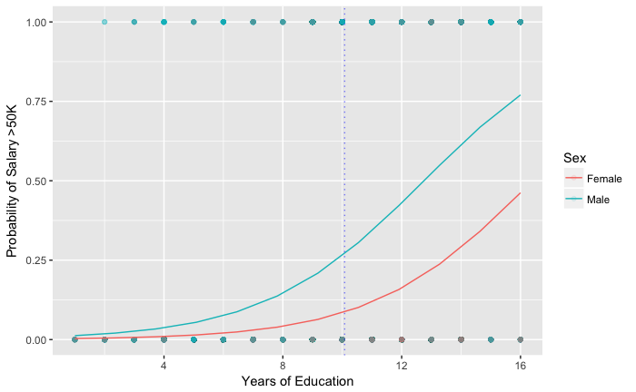

```r
fake_data <- data_grid(data, Sex, Education_Years=seq_range(Education_Years, 12)) %>% add_predictions(education_gender_model) %>% mutate(prob=plogis(pred))
ggplot(data) + geom_point(aes(Education_Years, Salary, color=Sex), alpha = 0.1) + geom_line(aes(Education_Years, prob, color=Sex), data=fake_data) + labs(x="Years of Education", y="Probability of Salary >50K") + geom_vline(xintercept = average_education_years, color="blue", alpha = 0.5, linetype="dotted")
```

##### 6. Is there an interaction between Gender and Years of Education on the influence on an individuals Salary?

```r
interaction_model <- glm(Salary ~ Sex * Education_Years, data=data, family=binomial(logit))
odds_and_probs(interaction_model, odds = c(1, 3, 4))
```

|  | Estimate | Odds(ratio) | Probability | Std. Error | p-value | Significance | z value |
| --- | --- | --- | --- | --- | --- | --- | --- |
| (Intercept) | -6.41665988 | 0.001634105 | 0.001631439 | 0.17820518 | 6.466300e-284 | *** | -36.007146 |
| SexMale | 1.73222368 | NA | NA | 0.19494238 | 6.344883e-19 | *** | 8.885824 |
| Education_Years | 0.39911805 | 1.490509565 | NA | 0.01523927 | 3.445874e-151 | *** | 26.190095 |
| SexMale:Education_Years | -0.03263139 | 0.967895267 | NA | 0.01682088 | 5.238772e-02 | . | -1.939934 |

```r
predicted_probabilities(interaction_model, data, variable_name = "Education_Years", variable_value = average_education_years)
```

| Sex | Predicted Value | Odds | Probability |
| --- | --- | --- | --- |
| Female | -2.3932788 | 0.09132974 | 0.08368666 |
| Male | -0.9900017 | 0.37157605 | 0.27091174 |

```r
pseudo_r2(interaction_model)
```

```
$McFadden
[1] 0.1600606

$CoxSnell
[1] 0.1619776

$Nagelkerke
[1] 0.1619776
```

```r
temp_data <- predicted_data(interaction_model, data)
predictive_percentage(temp_data)
```

| Accuracy | Baseline.Difference |
| --- | --- |
| 78.57253 | 2.653481 |

```r
confusion_matrix(temp_data)
```

```
      Guess
Salary     0     1
     0 22285  2435
     1  4542  3299
```

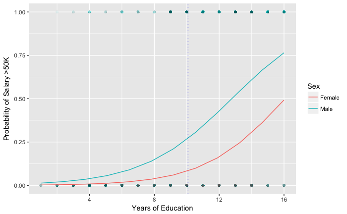

```r
fake_data <- data_grid(data, Sex, Education_Years=seq_range(Education_Years, 12)) %>% add_predictions(interaction_model) %>% mutate(prob=plogis(pred))
ggplot(data) + geom_point(aes(Education_Years, Salary, color=Sex), alpha = 0.012) + geom_line(aes(Education_Years, prob, color=Sex), data=fake_data) + labs(x="Years of Education", y="Probability of Salary >50K") + geom_vline(xintercept = average_education_years, color="blue", alpha = 0.5, linetype="dotted")
```

##### 7. Does the Working Class of an individual affect their salary?

```r
class_model <- glm(Salary ~ Work_Class, data=data, family=binomial(logit))
odds_and_probs(class_model)
```

|  | Estimate | Odds(ratio) | Probability | Std. Error | p-value | Significance | z value |
| --- | --- | --- | --- | --- | --- | --- | --- |
| (Intercept) | -2.1532222 | 0.1161094 | 0.1040305 | 0.07644282 | 1.452840e-174 | *** | -28.16774965 |
| Work_ClassFederal-gov | 1.6909981 | NA | NA | 0.10117665 | 1.048276e-62 | *** | 16.71332301 |
| Work_ClassLocal-gov | 1.2810003 | NA | NA | 0.09023169 | 9.590655e-46 | *** | 14.19678953 |
| Work_ClassNever-worked | -10.4128408 | NA | NA | 122.74160375 | 9.323922e-01 |  | -0.08483546 |
| Work_ClassPrivate | 0.8798053 | NA | NA | 0.07811138 | 1.987710e-29 | *** | 11.26347154 |
| Work_ClassSelf-emp-inc | 2.3836268 | NA | NA | 0.09734225 | 2.028399e-132 | *** | 24.48707364 |
| Work_ClassSelf-emp-not-inc | 1.2330716 | NA | NA | 0.08817640 | 1.948053e-44 | *** | 13.98414449 |
| Work_ClassState-gov | 1.1685054 | NA | NA | 0.09866391 | 2.331230e-32 | *** | 11.84329070 |
| Work_ClassWithout-pay | -10.4128408 | NA | NA | 86.79143718 | 9.045026e-01 |  | -0.11997544 |

```r
predicted_probabilities(class_model, data, pivot_variable = "Work_Class")
```

| Work_Class | Predicted Value | Odds | Probability |
| --- | --- | --- | --- |
| ? | -2.1532222 | 1.161094e-01 | 1.040305e-01 |
| Federal-gov | -0.4622241 | 6.298812e-01 | 3.864583e-01 |
| Local-gov | -0.8722220 | 4.180217e-01 | 2.947922e-01 |
| Never-worked | -12.5660630 | 3.488415e-06 | 3.488403e-06 |
| Private | -1.2734169 | 2.798737e-01 | 2.186729e-01 |
| Self-emp-inc | 0.2304046 | 1.259109e+00 | 5.573477e-01 |
| Self-emp-not-inc | -0.9201507 | 3.984590e-01 | 2.849272e-01 |
| State-gov | -0.9847169 | 3.735450e-01 | 2.719569e-01 |
| Without-pay | -12.5660630 | 3.488415e-06 | 3.488403e-06 |

```r
pseudo_r2(class_model)
```

```
$McFadden
[1] 0.02708692

$CoxSnell
[1] 0.02946185

$Nagelkerke
[1] 0.02946185
```

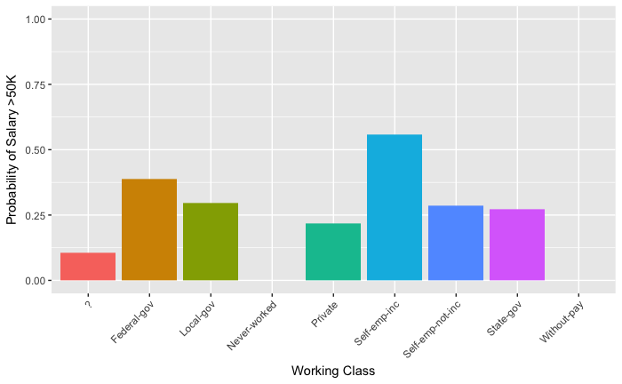

```r
fake_data <- data_grid(data, Work_Class) %>% add_predictions(class_model) %>% mutate(prob = plogis(pred))
ggplot(fake_data) + geom_bar(aes(Work_Class, prob, fill=Work_Class), stat="identity", show.legend=FALSE) + ylim(0,1) + labs(x="Working Class", y="Probability of Salary >50K")  + theme(axis.text.x = element_text(angle = 45, hjust = 1))
```

```r
hour_model <- glm(Salary ~ Hours_Per_Week, data=data, family=binomial(logit))
odds_and_probs(hour_model, odds = c(1, 2))
```

|  | Estimate | Odds(ratio) | Probability | Std. Error | p-value | Significance | z value |
| --- | --- | --- | --- | --- | --- | --- | --- |
| (Intercept) | -3.10007435 | 0.04504585 | 0.04310419 | 0.052897617 | 0 | *** | -58.60518 |
| Hours_Per_Week | 0.04645013 | 1.04754583 | NA | 0.001184449 | 0 | *** | 39.21667 |

```r
pseudo_r2(hour_model)
```

```
$McFadden
[1] 0.04897805

$CoxSnell
[1] 0.05263693

$Nagelkerke
[1] 0.05263693
```

```r
temp_data <- predicted_data(hour_model, data)
predictive_percentage(temp_data)
```

| Accuracy | Baseline.Difference |
| --- | --- |
| 75.19118 | -0.7278646 |

```r
confusion_matrix(temp_data)
```

```
      Guess
Salary     0     1
     0 24199   521
     1  7557   284
```

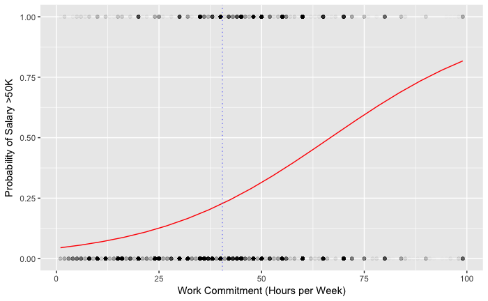

```r
fake_data <- data_grid(data, Hours_Per_Week=seq_range(Hours_Per_Week, 20)) %>% add_predictions(hour_model) %>% mutate(prob = plogis(pred))
ggplot(data) + geom_point(aes(Hours_Per_Week, Salary), alpha = 0.012) + geom_line(aes(Hours_Per_Week, prob), data=fake_data, color="red") + labs(x="Work Commitment (Hours per Week)", y="Probability of Salary >50K") + geom_vline(xintercept = mean(data$Hours_Per_Week), color = "blue", alpha = 0.5, linetype="dotted")
```

### 9. Effect of hours Per Week and Years of Education

```r
multiple_cont_model <- glm(Salary ~ Hours_Per_Week + Education_Years, data=data, family=binomial(logit))
odds_and_probs(multiple_cont_model, odds = c(1, 2, 3))
```

|  | Estimate | Odds(ratio) | Probability | Std. Error | p-value | Significance | z value |
| --- | --- | --- | --- | --- | --- | --- | --- |
| (Intercept) | -6.53806962 | 0.00144728 | 0.001445188 | 0.088971119 | 0.000000e+00 | *** | -73.48530 |
| Hours_Per_Week | 0.04072015 | 1.04156059 | NA | 0.001233339 | 4.759224e-239 | *** | 33.01618 |
| Education_Years | 0.34611804 | 1.41356947 | NA | 0.006393868 | 0.000000e+00 | *** | 54.13281 |

```r
pseudo_r2(multiple_cont_model)
```

```
$McFadden
[1] 0.1455427

$CoxSnell
[1] 0.1484375

$Nagelkerke
[1] 0.1484375
```

```r
temp_data <- predicted_data(multiple_cont_model, data)
predictive_percentage(temp_data)
```

| Accuracy | Baseline.Difference |
| --- | --- |
| 78.12721 | 2.208163 |

```r
confusion_matrix(temp_data)
```

```
      Guess
Salary     0     1
     0 23762   958
     1  6164  1677
```

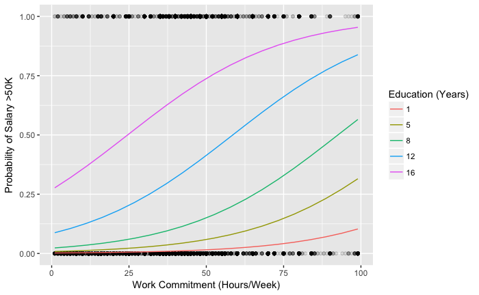

```r
fake_data <- data_grid(data, Hours_Per_Week=seq_range(Hours_Per_Week, 20), Education_Years=seq_range(Education_Years, 5)) %>%
  mutate(Education_Years=round(Education_Years)) %>% add_predictions(multiple_cont_model) %>% mutate(prob=plogis(pred), Education_Years = factor(Education_Years)) %>% rename(`Education (Years)` = Education_Years)
ggplot(data %>% rename(`Education (Years)` = Education_Years)) + geom_point(aes(Hours_Per_Week, Salary), alpha = 0.12) + geom_line(aes(Hours_Per_Week, prob, color=`Education (Years)`), data=fake_data) + labs(x="Work Commitment (Hours/Week)", y="Probability of Salary >50K")
```

### 10. Effect of hours Per Week interacting with Years of Education

```r
multiple_cont_interaction_model <- glm(Salary ~ Hours_Per_Week * Education_Years, data=data, family=binomial(logit))
odds_and_probs(multiple_cont_interaction_model, odds = c(1, 2, 3, 4))
```

|  | Estimate | Odds(ratio) | Probability | Std. Error | p-value | Significance | z value |
| --- | --- | --- | --- | --- | --- | --- | --- |
| (Intercept) | -7.332271184 | 0.0006540863 | 0.0006536588 | 0.254228053 | 6.511492e-183 | *** | -28.841314 |
| Hours_Per_Week | 0.058803476 | 1.0605667939 | NA | 0.005530543 | 2.104026e-26 | *** | 10.632497 |
| Education_Years | 0.419856811 | 1.5217436430 | NA | 0.022941506 | 8.096467e-75 | *** | 18.301188 |
| Hours_Per_Week:Education_Years | -0.001679135 | 0.9983222738 | NA | 0.000499543 | 7.756453e-04 | *** | -3.361343 |

```r
pseudo_r2(multiple_cont_interaction_model)
```

```
$McFadden
[1] 0.145851

$CoxSnell
[1] 0.1487274

$Nagelkerke
[1] 0.1487274
```

```r
temp_data <- predicted_data(multiple_cont_interaction_model, data)
predictive_percentage(temp_data)
```

| Accuracy | Baseline.Difference |
| --- | --- |
| 78.09342 | 2.17438 |

```r
confusion_matrix(temp_data)
```

```
      Guess
Salary     0     1
     0 23732   988
     1  6145  1696
```

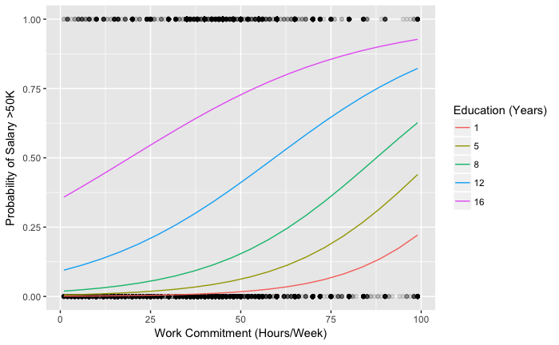

```r
fake_data <- data_grid(data, Hours_Per_Week=seq_range(Hours_Per_Week, 20), Education_Years=seq_range(Education_Years, 5)) %>%
  mutate(Education_Years=round(Education_Years)) %>% add_predictions(multiple_cont_interaction_model) %>% mutate(prob=plogis(pred), Education_Years = factor(Education_Years)) %>% rename(`Education (Years)` = Education_Years)
ggplot(data %>% rename(`Education (Years)` = Education_Years)) + geom_point(aes(Hours_Per_Week, Salary), alpha = 0.12) + geom_line(aes(Hours_Per_Week, prob, color=`Education (Years)`), data=fake_data) + labs(x="Work Commitment (Hours/Week)", y="Probability of Salary >50K")
```

##### 11. Does being full-time affect their salary?

```r
fulltime_model <- glm(Salary ~ Fulltime, data=data, family=binomial(logit))
odds_and_probs(fulltime_model)
```

|  | Estimate | Odds(ratio) | Probability | Std. Error | p-value | Significance | z value |
| --- | --- | --- | --- | --- | --- | --- | --- |
| (Intercept) | -2.253287 | 0.1050534 | 0.09506634 | 0.0386905 | 0.000000e+00 | *** | -58.23876 |
| FulltimeYes | 1.340522 | NA | NA | 0.0411613 | 1.182793e-232 | *** | 32.56752 |

```r
predicted_probabilities(fulltime_model, data, pivot_variable = "Fulltime")
```

| Fulltime | Predicted Value | Odds | Probability |
| --- | --- | --- | --- |
| No | -2.2532866 | 0.1050534 | 0.09506634 |
| Yes | -0.9127649 | 0.4014128 | 0.28643439 |

```r
pseudo_r2(fulltime_model)
```

```
$McFadden
[1] 0.0380226

$CoxSnell
[1] 0.04110894

$Nagelkerke
[1] 0.04110894
```

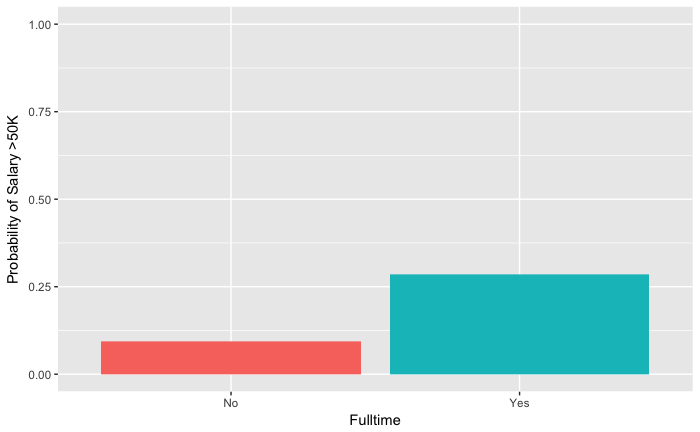

```r
fake_data <- data_grid(data, Fulltime) %>% add_predictions(fulltime_model) %>% mutate(prob = plogis(pred))
ggplot(fake_data) + geom_bar(aes(Fulltime, prob, fill=Fulltime), stat="identity", show.legend=FALSE) + ylim(0,1) + labs(x="Fulltime", y="Probability of Salary >50K")
```

##### 12. Controling for an individuals age, does an individuals hourly stats still influence their salary?

```r
fulltime_age_model <- glm(Salary ~ Fulltime + Age_Bin, data=data, family=binomial(logit))
odds_and_probs(fulltime_age_model)
```

|  | Estimate | Odds(ratio) | Probability | Std. Error | p-value | Significance | z value |
| --- | --- | --- | --- | --- | --- | --- | --- |
| (Intercept) | -5.129749 | 0.005918047 | 0.005883229 | 0.13277693 | 0.000000e+00 | *** | -38.63434 |
| FulltimeYes | 1.020122 | NA | NA | 0.04387517 | 1.404206e-119 | *** | 23.25056 |
| Age_Bin25 – 34 | 2.637831 | NA | NA | 0.13242655 | 2.773782e-88 | *** | 19.91920 |
| Age_Bin35 – 44 | 3.528446 | NA | NA | 0.13131799 | 4.995188e-159 | *** | 26.86948 |
| Age_Bin45 – 54 | 3.838211 | NA | NA | 0.13190701 | 3.821450e-186 | *** | 29.09785 |
| Age_Bin55 – 64 | 3.572724 | NA | NA | 0.13463951 | 3.777787e-155 | *** | 26.53548 |
| Age_Bin65+ | 3.291804 | NA | NA | 0.14642002 | 6.237290e-112 | *** | 22.48193 |

```r
data_grid(data, Age_Bin, Fulltime) %>%
    add_predictions(fulltime_age_model) %>%
    mutate(Odds = exp(pred),
           Probability = plogis(pred)) %>%
    rename(`Predicted Value` = pred)
```

| Age_Bin | Fulltime | Predicted Value | Odds | Probability |
| --- | --- | --- | --- | --- |
| 18 – 24 | No | -5.1297488 | 0.005918047 | 0.005883229 |
| 18 – 24 | Yes | -4.1096268 | 0.016413899 | 0.016148834 |
| 25 – 34 | No | -2.4919177 | 0.082751121 | 0.076426724 |
| 25 – 34 | Yes | -1.4717957 | 0.229512983 | 0.186669833 |
| 35 – 44 | No | -1.6013031 | 0.201633600 | 0.167799569 |
| 35 – 44 | Yes | -0.5811811 | 0.559237484 | 0.358660877 |
| 45 – 54 | No | -1.2915379 | 0.274847774 | 0.215592622 |
| 45 – 54 | Yes | -0.2714159 | 0.762299426 | 0.432559538 |
| 55 – 64 | No | -1.5570247 | 0.210762228 | 0.174074004 |
| 55 – 64 | Yes | -0.5369026 | 0.584556038 | 0.368908404 |

[output cut: 2 more lines]

```r
pseudo_r2(fulltime_age_model)
```

```
$McFadden
[1] 0.1286354

$CoxSnell
[1] 0.132393

$Nagelkerke
[1] 0.132393
```

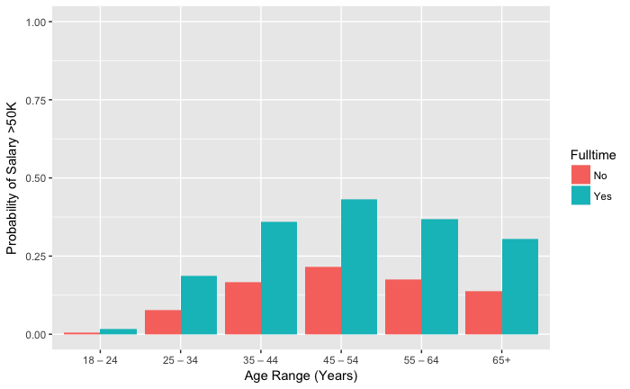

```r
fake_data <- data_grid(data, Fulltime, Age_Bin) %>% add_predictions(fulltime_age_model) %>% mutate(prob=plogis(pred))
ggplot(fake_data, aes(Age_Bin, prob)) + geom_bar(aes(fill = Fulltime), stat="identity", position = "dodge") + ylim(0,1) + labs(x="Age Range (Years)", y="Probability of Salary >50K")
```

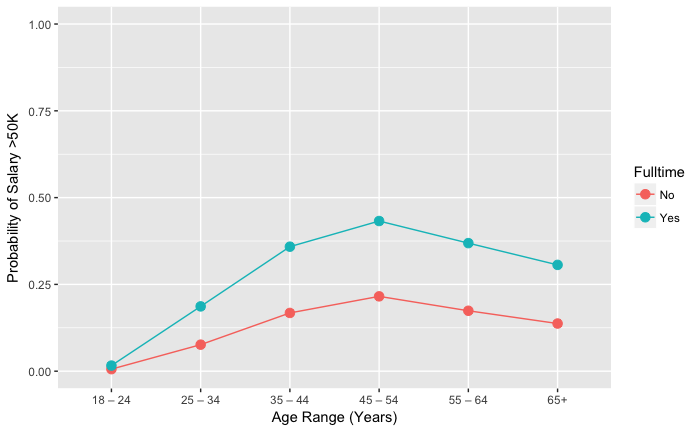

```r
ggplot(fake_data, aes(x=Age_Bin, y=prob, group=Fulltime, colour=Fulltime)) + geom_line() + geom_point(size=3) + ylim(0,1) + labs(y="Probability of Salary >50K", x="Age Range (Years)")
```